# 425 Project Report

Safiye Şahin - Ilayda Tutal

27 06 2021

## Introduction

Kobe Bean Bryant was an American professional basketball player. A shooting guard, he spent his entire 20-year career with the Los Angeles Lakers in the National Basketball Association (NBA). Regarded as one of the greatest basketball players of all time.

In this project, a data based on Kobe Bryant’s shots during his 20-year career is investigated. The goal is, to predict if the basket went in or not according to input variables in the data set such as location, distance, shot type, opponent and so on. There is given train set which is going to be used to build different models and a test set to test the goodness of these models in order to using the one which yields the best predictions.

## Manipulation

Firstly, for the manipulation part, it is realized that there are game id and game date variables which seems having a one to one relationship. If so, one of them is not necessary and can be excluded.

### Game ID & Game Date

```r
unique_gamedate <- unique(given_train$game_date)
length(unique_gamedate)
```

```
## [1] 1554
```

```r
unique_gameid <- unique(given_train$game_id)
length(unique_gameid)
```

```
## [1] 1554
```

```r
given_train <- given_train[, c("game_date"):=NULL]
```

As it is expected, there is one game for each date and this leads us to delete the date column. Moreover, it is time to see detailed and aggregated effects of input variables on output variable which is shot_made_flag. To start with, game ID is continued to be analyzed and it is realized that the game IDs are increasing numbers. So, the idea that there might be an increasing trend over the years has risen. It is meaningful thinking about the fact that people get better at their professions over the years. So, the game ID and shot rate is plotted. This idea of shot rate is used in different parts of this project and it basically represents the percentage of the baskets went in. For example, in the following plot, it is aimed to show for the each game ID, what percentage of the shots are went in. With this approach, rather that seeing the numbers, comparing and commenting on the percentage values are aimed and made more sense.

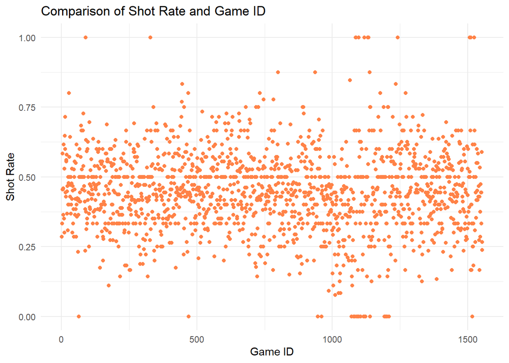

However, there is not a significant trend or seasonality in this plot that can allow us to create a new variable or manipulate further. Still, there are many other input variables that can be analyzed together.

### Combined Shot Type & Shot Type

Naturally, shot types are one of the most important inputs affecting the result of the shots. Therefore, again, with using the shot rate idea, it can be seen what percentage of a particular combined shot type leads the best shots. In the blow barplot, it is clear that there are 6 different combined shot types some of them yielded very good results and some of them are not the best choice to use. But the more obvious the effect, the better the manipulating since it is desired for the model to differentiate a shot easily.

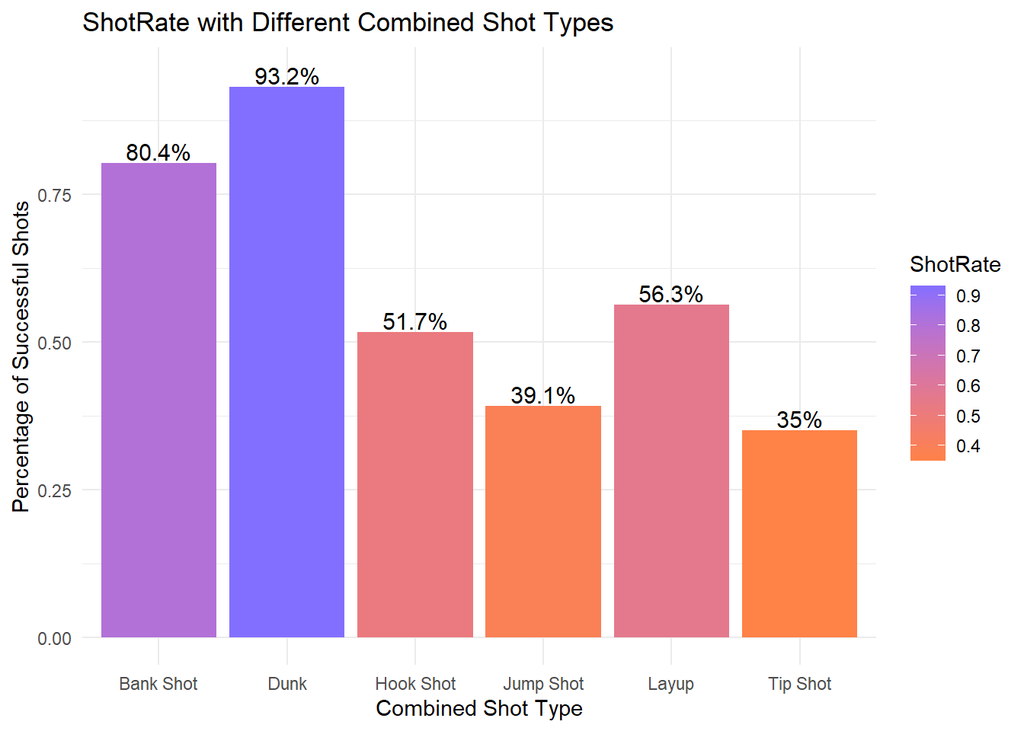

With this rationality, it is obvious that if Kobe uses a dunk in his combined shot type, there is a very high probability of success for that shot. It is not a surprising result thinking about the fact that dunk is a shot that is thrown very near of the basket. So, it is thought that marking the shots with combined_shot_type == “Dunk” as 1 and others as 0 seems reasonable.

### Location

Talking about the locations, there are four attributes which represent the locations on the field where all these shots are made. It is a good idea to plot these and see the field and the successful shots visually.

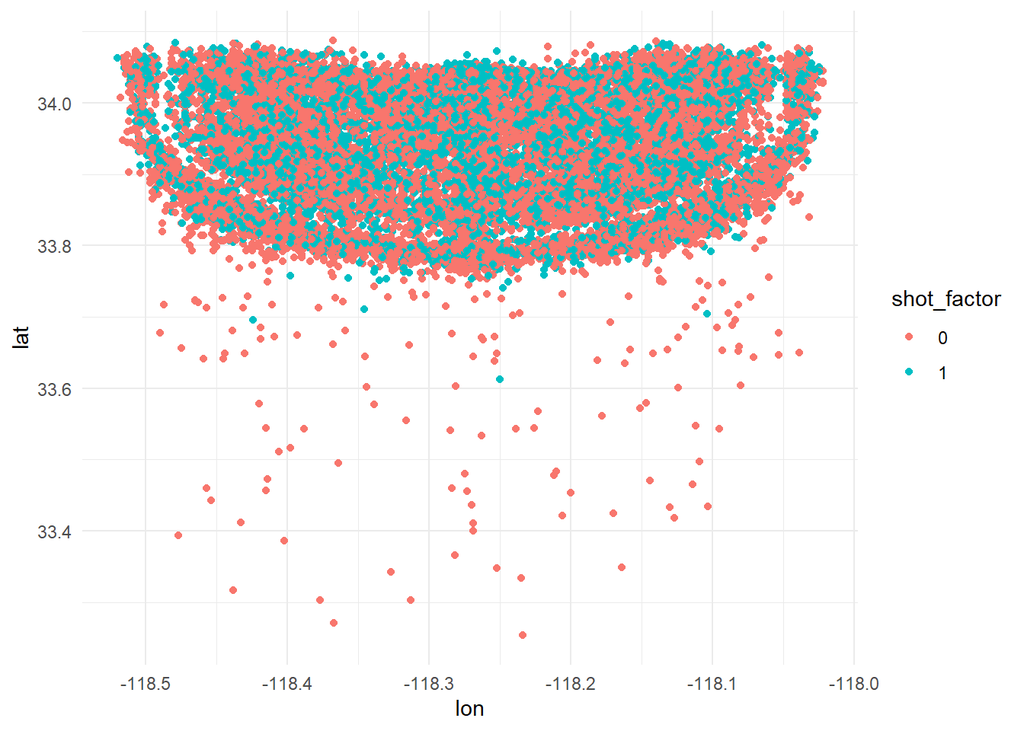

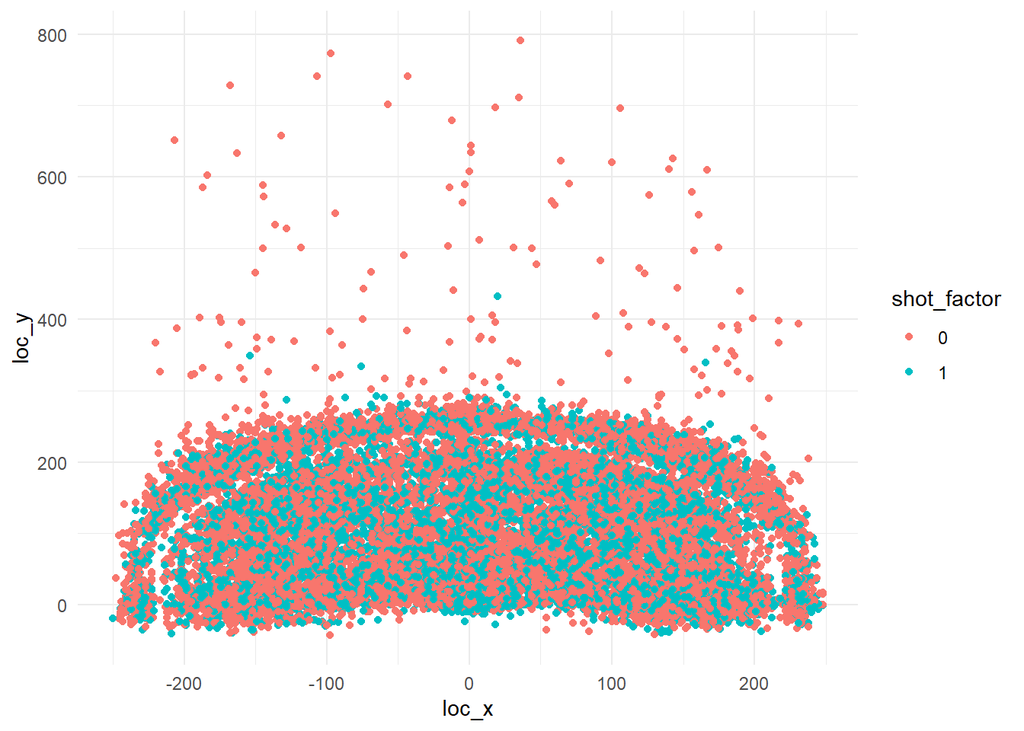

It seems like lat and lon have a similar representative value as loc_x and loc_y. Because of the shape of the distribution of these points, zero point must be the basket. The thin white empty area is probably the 3pt line and he seems to have secured 3 points by staying behind the 3 point line.

Since the shapes of these distributed points are half circle, it might be a good idea to represent these as polar coordinates and plot again to see another visualization.

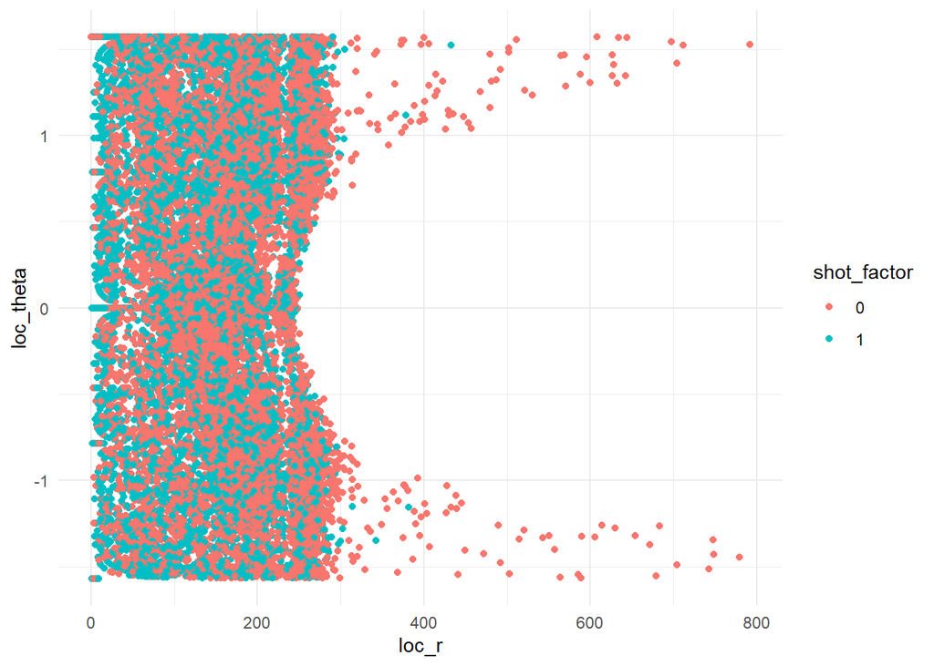

With the new polar coordinate variables loc_r and loc_theta, again, the objective is seeing an obvious affect that can be added as a new variable or manipulate to predict better. Hence, a threshold r value as 270 and theta values as 1 and -1 seems meaningful to show the effect of these new variables. So, another new variable named too_far is added to represent the shots with r value more that 270 or theta value more than 1 or less than -1 are marked as 1 with the help of this one. It is expected to model the effect of the location on the shots better with these part of the manipulations.

### Remaining Time

Next, remaining time might have a various affect on the shots. It is good to see the time remaining and color the shots to see if there is an obvious pattern or effect.

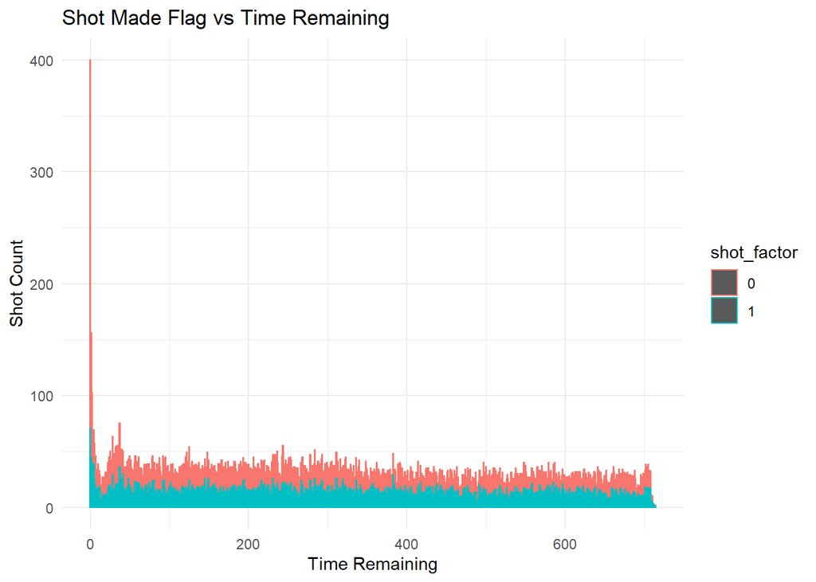

```r
#time remaining
given_train$time_remaining <- (given_train$minutes_remaining * 60) + given_train$seconds_remaining
ggplot(given_train, aes(x = time_remaining, color = shot_factor)) + geom_bar() +
  labs(title = "Shot Made Flag vs Time Remaining", x = "Time Remaining", y = "Shot Count") +
  theme_minimal()
```

```r
given_train$lastminutes <- ifelse(given_train$time_remaining <= 180, 1, 0)
given_train[, c("minutes_remaining", "seconds_remaining"):=NULL]
```

### Team ID & Team Name

Team_id and Team_name seems not having more than 1 level. They’re meaningless

```r
#team_id and team_name seems not having more than 1 value. they're meaningless
length(unique(given_train$team_name))
```

```
## [1] 1
```

```r
length(unique(given_train$team_id))
```

```
## [1] 1
```

```r
given_train <- given_train[, c("team_name","team_id"):=NULL]
```

### Home & Away

Another thing is that if the match is played in the field of LA Lakers or in the opponents’ field. It is a well known phenomena in the sports that playing on their own vs others’ field have a different impact on players’ confidence and stress level in general. The matchup attribute gives signals for this one such as LAL @ POR means the match is on LA Lakers’ field, on the other hand; LAL vs LAC means that the match is played on the Los Angeles Clippers’ field. It might be a good move to add a variable named home to represent this difference in the matchups. Here is the first 10 observations in the matchup column.

```r
given_train$home <- 0
given_train$matchup[(1:10)]
```

```
##  [1] LAL @ POR   LAL @ POR   LAL @ POR   LAL @ POR   LAL @ POR   LAL @ POR
##  [7] LAL @ POR   LAL vs. UTA LAL vs. UTA LAL vs. UTA
## 74 Levels: LAL @ ATL LAL @ BKN LAL @ BOS LAL @ CHA LAL @ CHH ... LAL vs. WAS
```

```r
given_train[grepl( "@", given_train$matchup, fixed = TRUE) == TRUE, home:= 1]
given_train[, c("matchup"):=NULL]
```

### Season

Different seasons may have different dynamics and the performance of players can be affected from these. Therefore, it may be a useful finding for manipulation to plot successful and unsuccessful shots according to the seasons and to check whether there is a pattern in which success or failure is dominant.

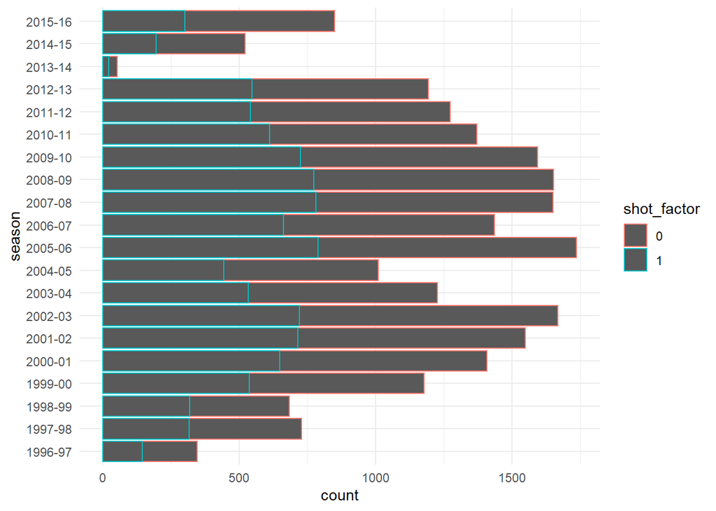

When it is examined deeply, it can be seen that the plot obtained in this way does not present very clear findings.However, if the shot rate data can be seen numerically rather than the number of successful and unsuccessful shots according to the season, a treshold value can be determined and the performance in the seasons can be interpreted more clearly. Following plot shows the Shot Rate( succesful shots/ total) according to seasons.

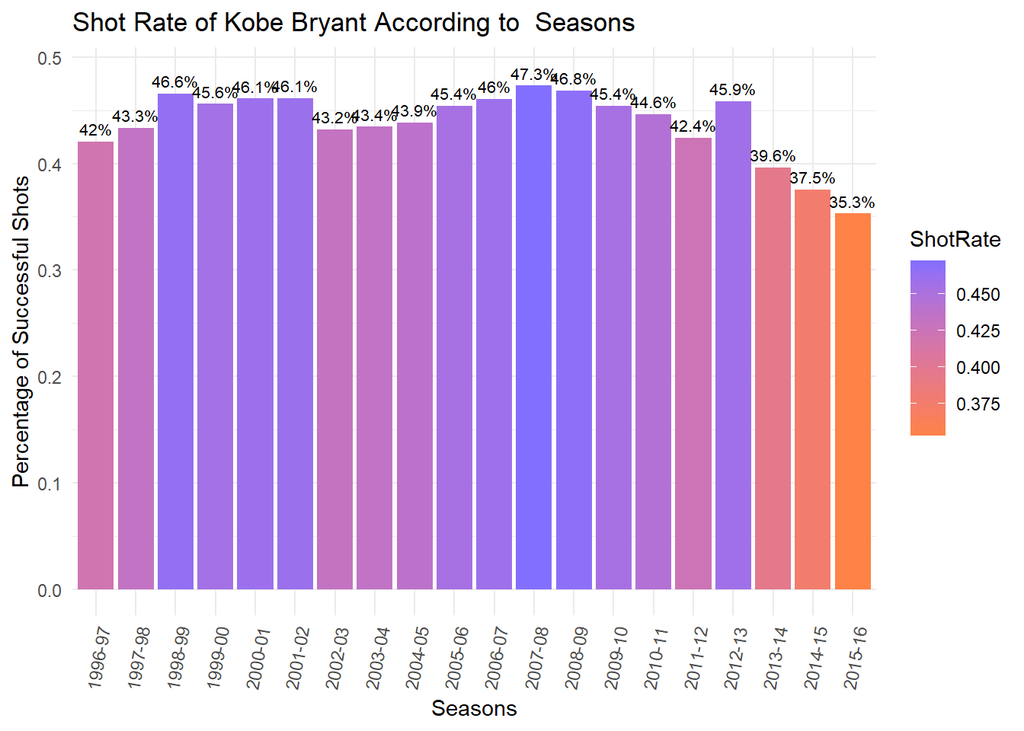

When the graph is examined, it can be observed that shot rates have decreased in last seasons, in this case it would be a good approach to mark these seasons as a new input attribute (last seasons).

### Opponent

In the data, there is information about the shots against 33 different opponents, and it is inevitable to think that the different opponents can have different effect on success of shots. In addition,it is known that in sports competitions, whether the match is played on the team’s own field or on the opponent’s field is one of the significant factors affecting the performance of the team.

Therefore, plotting the shot rate in home matches according to the each opponent can make it easier to get an idea of the performance of Kobe Bryant.

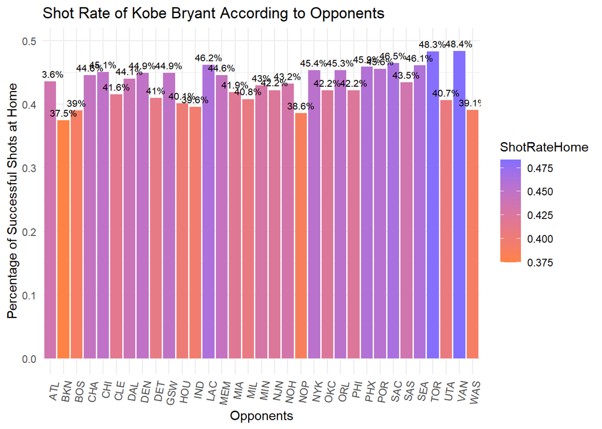

```r
#length(unique(given_train$opponent)) #33 opponents

opponents = data.table(Opponents=unique(given_train$opponent), ShotRateHome=rep(0,33))

for (i in unique(given_train$opponent)){
  opponents[Opponents==i, ShotRateHome:=mean(given_train[opponent==i & home==1]$shot_made_flag)]

}

ggplot(opponents, aes(x=Opponents, y=ShotRateHome, fill=ShotRateHome)) +
  geom_bar(stat='identity') + scale_fill_continuous(low="sienna1", high="slateblue1") +
  labs(title = "Shot Rate of Kobe Bryant According to Opponents",
       x = "Opponents",
       y = "Percentage of Successful Shots at Home") +
  geom_text(data=opponents, aes(label=paste0(round(ShotRateHome*100,1),"%"),
                                y=ShotRateHome+0.012), size=2.8) + theme_minimal()+
  theme(axis.text.x = element_text(angle = 80, hjust = 1))
```

```r
given_train[, special_opp:=0]
given_train[home==1 & (opponent== "BKN" | opponent== "BOS" | opponent== "CLE" | opponent== "DET" |
                         opponent== "HOU" | opponent== "IND" | opponent== "MIL" | opponent== "NOP" |
                         opponent== "WAS" | opponent== "UTA"), special_opp:=1]
```

When the plot is examined, it can be observed that the rate of shot against some teams is relatively low compared to others. Threshold value is determined as 41.6% and matches played at home with opponents whose shot rate below this value can be defined as a new variable (special_opp).

### Manipulated Version of Training Set

After the manipulations on the training set, structure of it and newly added input attributes can be seen below.

```
## Classes 'data.table' and 'data.frame':   23127 obs. of  25 variables:
##  $ X                 : int  1 2 3 4 5 8 9 10 11 12 ...
##  $ action_type       : Factor w/ 55 levels "Alley Oop Dunk Shot",..: 26 26 26 5 26 41 26 26 41 26 ...
##  $ combined_shot_type: Factor w/ 6 levels "Bank Shot","Dunk",..: 4 4 4 2 4 4 4 4 4 4 ...
##  $ game_event_id     : int  12 35 43 155 244 294 309 4 27 66 ...
##  $ game_id           : int  20000012 20000012 20000012 20000012 20000012 20000012 20000012 20000019 20000019 20000019 ...
##  $ period            : int  1 1 1 2 3 3 3 1 1 1 ...
##  $ playoffs          : int  0 0 0 0 0 0 0 0 0 0 ...
##  $ season            : Factor w/ 20 levels "1996-97","1997-98",..: 5 5 5 5 5 5 5 5 5 5 ...
##  $ shot_distance     : int  15 16 22 0 14 12 25 17 12 9 ...
##  $ shot_made_flag    : Factor w/ 2 levels "0","1": 1 2 1 2 1 1 1 2 2 1 ...
##  $ shot_type         : Factor w/ 2 levels "2PT Field Goal",..: 1 1 1 1 1 1 2 1 1 1 ...
##  $ shot_zone_area    : Factor w/ 6 levels "Back Court(BC)",..: 4 3 5 2 4 2 3 5 4 4 ...
##  $ shot_zone_basic   : Factor w/ 7 levels "Above the Break 3",..: 5 5 5 6 5 3 1 5 3 5 ...
##  $ shot_zone_range   : Factor w/ 5 levels "16-24 ft.","24+ ft.",..: 3 1 1 5 3 3 2 1 3 3 ...
##  $ opponent          : Factor w/ 33 levels "ATL","BKN","BOS",..: 26 26 26 26 26 26 26 31 31 31 ...
##  $ shot_factor       : Factor w/ 2 levels "0","1": 1 2 1 2 1 1 1 2 2 1 ...
##  $ is_dunk           : num  0 0 0 1 0 0 0 0 0 0 ...
##  $ loc_r             : num  157 169 223 0 145 ...
##  $ loc_theta         : num  0 -0.9285 0.9031 1.5708 0.0757 ...
##  $ too_far           : num  0 0 0 1 0 1 1 0 1 0 ...
##  $ time_remaining    : num  622 465 412 379 572 216 116 660 429 164 ...
##  $ lastminutes       : num  0 0 0 0 0 0 1 0 0 1 ...
##  $ home              : num  1 1 1 1 1 1 1 0 0 0 ...
##  $ last_seasons      : num  0 0 0 0 0 0 0 0 0 0 ...
##  $ special_opp       : num  0 0 0 0 0 0 0 0 0 0 ...
##  - attr(*, ".internal.selfref")=<externalptr>
##  - attr(*, "index")= int
##   ..- attr(*, "__game_id")= int
```

## Modelling

### Tree

In order to observe the progress in the modeling process, it is preferred to use different methods step by step. As a first step, it has been tried to model the train set, which is obtained by splitting the given tarining set, by tree. However , it is not a suitable method for this data because input attributes contain too many levels.

```r
#tree
library(tree)
tr1 = tree(shot_made_flag~., data=train, mincut=1, minsize=2, mindev=0.0)
```

```
## Error in tree(shot_made_flag ~ ., data = train, mincut = 1, minsize = 2, : factor predictors must have at most 32 levels
```

### Random Forest

The caret package (Classification And REgression Training) contains functions to streamline the model training process for complex regression and classification problems. Caret has several functions that attempt to streamline the model building and evaluation process, as well as feature selection and other techniques. It is decided to use the caret package in order to choose the best model to fit train set.

The purpose of using cross-validation is to make you more confident to the model trained on the training set. Without cross-validation, model may perform well on the training set, but the performance decreases when applied to the testing set.Since the run time of the model is very long when the cv value is selected as 10, values that can give results in a more reasonable time have been tried (7,8).

In addition, when the random forest method is tried, because result is not efficients in terms of time ,it is decided not to continue with this.

```r
#library(caret)
#ctrl1 = trainControl(method = "cv", number = 8)
#fit1 = train(shot_made_flag~., data=train, method= "rf", metric="ShotRate", ntree=100, trControl = ctrl1, tuneGrid = expand.grid(.mtry = (1:5)))
```

### GBM

After trying different methods, it is decided that the gradient boosting machine would be the most suitable method for the data set in hand. Below variables used in the expand.grid are seen. - While the *n tree* value was desired to be selected high in order to reduce the error it was chosen in an average range considering the run time length and the possibility of overfitting.

-*interaction.depth* (Maximum nodes per tree) is determined to change between 3 and 5, we noticed that this value is always in these ranges in models in general.

-*shrinkage* (Learning Rate) is tried as (1:2)*0.1 , because high learn rates and especially values close to 1.0 typically result in overfit models with poor performance. Values much smaller than .01 significantly slow down the learning process and might be reserved for overnight. runs.

-*n.minobsinnode* (the minimum number of observations in trees’ terminal nodes.) Setting n.minobsinnode = 10 or 20 can give good results. When working with small training samples it may be vital to lower this setting to five or even three.

```r
library(caret)
library(gbm)
ctrl1 = trainControl(method = "cv", number = 8)

ctrl2 = trainControl(method = "cv", number = 7)

gbmGrid=expand.grid(interaction.depth = c(3, 4),
                    n.trees = c(130, 140),
                    shrinkage = (1:2)*0.1,
                    n.minobsinnode = c(10, 20))


gbmGrid2 =expand.grid(interaction.depth = c(4, 5),
                    n.trees = c(130, 140),
                    shrinkage = (1:2)*0.1,
                    n.minobsinnode = c(10, 20))
```

In order to choose the best fit for prediction, gmb fits containing different variables are tested with the test set splitting from the given train. Roc curves of four fit (there are very minor differences )and auc values of fits can be seen below. According to trials the best auc value is 0.6661 and it is reached when ctrl2 and gbmGrid2 are used in the fit. Therefore, to predict the model using actual test set , this fit should be selected.

```
## Stochastic Gradient Boosting
##
## 16189 samples
##    24 predictor
##     2 classes: '0', '1'
##
## No pre-processing
## Resampling: Cross-Validated (8 fold)
## Summary of sample sizes: 14165, 14166, 14165, 14166, 14166, 14165, ...
## Resampling results across tuning parameters:
##
##   shrinkage  interaction.depth  n.minobsinnode  n.trees  Accuracy   Kappa
##   0.1        3                  10              130      0.6790415  0.3270299
##   0.1        3                  10              140      0.6779294  0.3248855
##   0.1        3                  20              130      0.6797206  0.3285583
##   0.1        3                  20              140      0.6796588  0.3283418
##   0.1        4                  10              130      0.6781762  0.3251181
##   0.1        4                  10              140      0.6785469  0.3260097
##   0.1        4                  20              130      0.6799064  0.3289532
##   0.1        4                  20              140      0.6794120  0.3279554
##   0.2        3                  10              130      0.6731115  0.3159386
##   0.2        3                  10              140      0.6729879  0.3155939
##   0.2        3                  20              130      0.6768790  0.3234941
##   0.2        3                  20              140      0.6775586  0.3250083
##   0.2        4                  10              130      0.6728016  0.3156640
##   0.2        4                  10              140      0.6726778  0.3155310
##   0.2        4                  20              130      0.6713816  0.3133529
##   0.2        4                  20              140      0.6695285  0.3097515
##
## Accuracy was used to select the optimal model using the largest value.
## The final values used for the model were n.trees = 130, interaction.depth =
##  4, shrinkage = 0.1 and n.minobsinnode = 20.
```

```
## Area under the curve: 0.6659
```

```
## Stochastic Gradient Boosting
##
## 16189 samples
##    24 predictor
##     2 classes: '0', '1'
##
## No pre-processing
## Resampling: Cross-Validated (7 fold)
## Summary of sample sizes: 13876, 13876, 13878, 13876, 13876, 13876, ...
## Resampling results across tuning parameters:
##
##   shrinkage  interaction.depth  n.minobsinnode  n.trees  Accuracy   Kappa
##   0.1        3                  10              130      0.6801551  0.3293256
##   0.1        3                  10              140      0.6799699  0.3290436
##   0.1        3                  20              130      0.6798463  0.3289488
##   0.1        3                  20              140      0.6799082  0.3289923
##   0.1        4                  10              130      0.6797226  0.3284276
##   0.1        4                  10              140      0.6797842  0.3285118
##   0.1        4                  20              130      0.6789197  0.3270200
##   0.1        4                  20              140      0.6791049  0.3274736
##   0.2        3                  10              130      0.6776846  0.3253610
##   0.2        3                  10              140      0.6757697  0.3213422
##   0.2        3                  20              130      0.6746578  0.3189141
##   0.2        3                  20              140      0.6745960  0.3192022
##   0.2        4                  10              130      0.6725577  0.3151959
##   0.2        4                  10              140      0.6727426  0.3160062
##   0.2        4                  20              130      0.6775606  0.3257526
##   0.2        4                  20              140      0.6773138  0.3253861
##
## Accuracy was used to select the optimal model using the largest value.
## The final values used for the model were n.trees = 130, interaction.depth =
##  3, shrinkage = 0.1 and n.minobsinnode = 10.
```

```
## Area under the curve: 0.6659
```

```
## Stochastic Gradient Boosting
##
## 16189 samples
##    24 predictor
##     2 classes: '0', '1'
##
## No pre-processing
## Resampling: Cross-Validated (7 fold)
## Summary of sample sizes: 13876, 13876, 13876, 13876, 13878, 13876, ...
## Resampling results across tuning parameters:
##
##   shrinkage  interaction.depth  n.minobsinnode  n.trees  Accuracy   Kappa
##   0.1        4                  10              130      0.6791022  0.3272417
##   0.1        4                  10              140      0.6784226  0.3260469
##   0.1        4                  20              130      0.6786080  0.3261800
##   0.1        4                  20              140      0.6785461  0.3260402
##   0.1        5                  10              130      0.6786075  0.3261760
##   0.1        5                  10              140      0.6781754  0.3253504
##   0.1        5                  20              130      0.6796580  0.3285810
##   0.1        5                  20              140      0.6788551  0.3270196
##   0.2        4                  10              130      0.6752110  0.3211781
##   0.2        4                  10              140      0.6718135  0.3145390
##   0.2        4                  20              130      0.6725553  0.3160004
##   0.2        4                  20              140      0.6717522  0.3144713
##   0.2        5                  10              130      0.6722461  0.3152391
##   0.2        5                  10              140      0.6721230  0.3155445
##   0.2        5                  20              130      0.6722461  0.3152967
##   0.2        5                  20              140      0.6719992  0.3151148
##
## Accuracy was used to select the optimal model using the largest value.
## The final values used for the model were n.trees = 130, interaction.depth =
##  5, shrinkage = 0.1 and n.minobsinnode = 20.
```

```
## Area under the curve: 0.6661
```

```
## Stochastic Gradient Boosting
##
## 16189 samples
##    24 predictor
##     2 classes: '0', '1'
##
## No pre-processing
## Resampling: Cross-Validated (8 fold)
## Summary of sample sizes: 14165, 14165, 14165, 14165, 14165, 14166, ...
## Resampling results across tuning parameters:
##
##   shrinkage  interaction.depth  n.minobsinnode  n.trees  Accuracy   Kappa
##   0.1        4                  10              130      0.6795355  0.3281912
##   0.1        4                  10              140      0.6793502  0.3279610
##   0.1        4                  20              130      0.6791032  0.3273801
##   0.1        4                  20              140      0.6795973  0.3283801
##   0.1        5                  10              130      0.6798443  0.3290184
##   0.1        5                  10              140      0.6794735  0.3281842
##   0.1        5                  20              130      0.6785473  0.3260914
##   0.1        5                  20              140      0.6787327  0.3265320
##   0.2        4                  10              130      0.6750880  0.3203030
##   0.2        4                  10              140      0.6737290  0.3177962
##   0.2        4                  20              130      0.6749645  0.3205103
##   0.2        4                  20              140      0.6750881  0.3211119
##   0.2        5                  10              130      0.6733581  0.3181492
##   0.2        5                  10              140      0.6738526  0.3194287
##   0.2        5                  20              130      0.6737903  0.3189342
##   0.2        5                  20              140      0.6724312  0.3167641
##
## Accuracy was used to select the optimal model using the largest value.
## The final values used for the model were n.trees = 130, interaction.depth =
##  5, shrinkage = 0.1 and n.minobsinnode = 10.
```

```
## Area under the curve: 0.6654
```

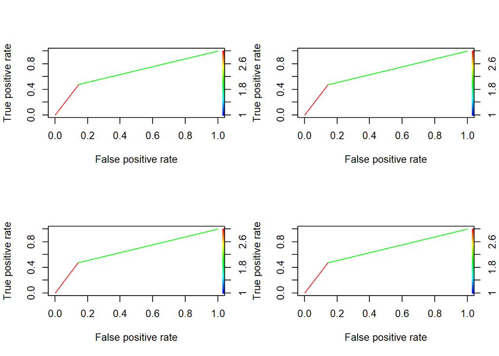

## Result

In conclusion, data based on the Kobe Bryant’s 20-year career is used to predict if his shots went in or not according to the input variables such as location, shot distance, shot type, remaining time as well as the newly added variables such as is_dunk, home, last_minutes, or special_opp.

When the shot_made_flag is predicted using the given test set and the selected fit, accuracy value is found as 0.71498.